# Feature_selection

```python
import pandas as pd
import numpy as np
data = pd.read_csv("data/diabetes.csv")
data.head()
```

|  | Pregnancies | Glucose | BloodPressure | SkinThickness | Insulin | BMI | DiabetesPedigreeFunction | Age | Outcome |
| --- | --- | --- | --- | --- | --- | --- | --- | --- | --- |
| 0 | 6 | 148 | 72 | 35 | 0 | 33.6 | 0.627 | 50 | 1 |
| 1 | 1 | 85 | 66 | 29 | 0 | 26.6 | 0.351 | 31 | 0 |
| 2 | 8 | 183 | 64 | 0 | 0 | 23.3 | 0.672 | 32 | 1 |
| 3 | 1 | 89 | 66 | 23 | 94 | 28.1 | 0.167 | 21 | 0 |
| 4 | 0 | 137 | 40 | 35 | 168 | 43.1 | 2.288 | 33 | 1 |

```python
# проверка на пропуски
data.info()
```

```
<class 'pandas.core.frame.DataFrame'>
RangeIndex: 768 entries, 0 to 767
Data columns (total 9 columns):
 #   Column                    Non-Null Count  Dtype
---  ------                    --------------  -----
 0   Pregnancies               768 non-null    int64
 1   Glucose                   768 non-null    int64
 2   BloodPressure             768 non-null    int64
 3   SkinThickness             768 non-null    int64
 4   Insulin                   768 non-null    int64
 5   BMI                       768 non-null    float64
 6   DiabetesPedigreeFunction  768 non-null    float64
 7   Age                       768 non-null    int64
 8   Outcome                   768 non-null    int64
dtypes: float64(2), int64(7)
memory usage: 54.1 KB
```

**----- Что можно сказать о данном датасете? Готов ли он для обучения моделей методами машинного обучения?**

**Наша цель уменьшить количество признаков в датасете для упрощения расчетов и вероятного улучшения модели**  
**Для этого воспользуемся разными методами уменьшения размерности датасета**

### 1. Фильтр с низкой дисперсией

Рассмотрим переменную в нашем наборе данных, где все наблюдения имеют одинаковое значение, скажем 1. Если мы будем использовать эту переменную, как вы думаете, она может улучшить модель, которую мы построим? Ответ - нет, потому что эта переменная будет иметь нулевую дисперсию.

Итак, нам нужно рассчитать дисперсию каждой переменной, которая нам дана. Затем отбросьте переменные, имеющие низкую дисперсию по сравнению с другими переменными в нашем наборе данных. Причина этого заключается в том, что переменные с низкой дисперсией не влияют на целевую переменную.

```python
# посчитаем дисперсию всех числовых переменных
data.var()
```

```
Pregnancies                    11.354056
Glucose                      1022.248314
BloodPressure                 374.647271
SkinThickness                 254.473245
Insulin                     13281.180078
BMI                            62.159984
DiabetesPedigreeFunction        0.109779
Age                           138.303046
Outcome                         0.227483
dtype: float64
```

```python
# в этом приере столбец Outcome является столбцом меток Y, поэтому не будем учитывать его при формировании таблицы признаков
numeric = data[['Pregnancies','Glucose','BloodPressure','SkinThickness','Insulin','BMI','DiabetesPedigreeFunction','Age']]
var = numeric.var()
numeric = numeric.columns

variable = [ ]

for i in range(0,len(var)):
    if var[i]>=10:   # setting the threshold as 10%
       variable.append(numeric[i])
```

```python
variable
```

```
['Pregnancies',
 'Glucose',
 'BloodPressure',
 'SkinThickness',
 'Insulin',
 'BMI',
 'Age']
```

**можно заметить, что один из признаков удалился, какой и почему?**

```python
data_less=data[variable]
data_less
```

|  | Pregnancies | Glucose | BloodPressure | SkinThickness | Insulin | BMI | Age |
| --- | --- | --- | --- | --- | --- | --- | --- |
| 0 | 6 | 148 | 72 | 35 | 0 | 33.6 | 50 |
| 1 | 1 | 85 | 66 | 29 | 0 | 26.6 | 31 |
| 2 | 8 | 183 | 64 | 0 | 0 | 23.3 | 32 |
| 3 | 1 | 89 | 66 | 23 | 94 | 28.1 | 21 |
| 4 | 0 | 137 | 40 | 35 | 168 | 43.1 | 33 |
| ... | ... | ... | ... | ... | ... | ... | ... |
| 763 | 10 | 101 | 76 | 48 | 180 | 32.9 | 63 |
| 764 | 2 | 122 | 70 | 27 | 0 | 36.8 | 27 |
| 765 | 5 | 121 | 72 | 23 | 112 | 26.2 | 30 |
| 766 | 1 | 126 | 60 | 0 | 0 | 30.1 | 47 |
| 767 | 1 | 93 | 70 | 31 | 0 | 30.4 | 23 |

768 rows × 7 columns

**Теперь приступим к обучению на наших датасетах: начальном data и уменьшенном data_less**

```python
y = data["Outcome"] # Формируем вектор меток У
y
```

```
0      1
1      0
2      1
3      0
4      1
      ..
763    0
764    0
765    0
766    1
767    0
Name: Outcome, Length: 768, dtype: int64
```

```python
X = data.drop("Outcome", axis=1) # Формируем массив данных X, удаляем массив меток из начального датасета
X.head()
```

|  | Pregnancies | Glucose | BloodPressure | SkinThickness | Insulin | BMI | DiabetesPedigreeFunction | Age |
| --- | --- | --- | --- | --- | --- | --- | --- | --- |
| 0 | 6 | 148 | 72 | 35 | 0 | 33.6 | 0.627 | 50 |
| 1 | 1 | 85 | 66 | 29 | 0 | 26.6 | 0.351 | 31 |
| 2 | 8 | 183 | 64 | 0 | 0 | 23.3 | 0.672 | 32 |
| 3 | 1 | 89 | 66 | 23 | 94 | 28.1 | 0.167 | 21 |
| 4 | 0 | 137 | 40 | 35 | 168 | 43.1 | 2.288 | 33 |

**Обучение методом Решающих деревьев**

```python
from sklearn.tree import DecisionTreeClassifier
from sklearn.model_selection import cross_val_score, train_test_split
```

```python
X_train, X_valid, y_train, y_valid = train_test_split(   # 70% и 30%
    X, y, test_size=0.3, random_state=17)
```

```python
tree = DecisionTreeClassifier(random_state=17)
cross_val_score(tree, X_train, y_train, cv=5) # оценка модели с помощью кросс-валидации
```

```
array([0.7037037 , 0.66666667, 0.65420561, 0.74766355, 0.6635514 ])
```

```python
np.mean(cross_val_score(tree, X_train, y_train, cv=5)) #среднее по пяти оценкам
```

```
0.6871581862236067
```

**Формируем массив данных X из уменьшенного датасета data_less**

```python
X_less = data_less
X_less.head()
```

|  | Pregnancies | Glucose | BloodPressure | SkinThickness | Insulin | BMI | Age |
| --- | --- | --- | --- | --- | --- | --- | --- |
| 0 | 6 | 148 | 72 | 35 | 0 | 33.6 | 50 |
| 1 | 1 | 85 | 66 | 29 | 0 | 26.6 | 31 |
| 2 | 8 | 183 | 64 | 0 | 0 | 23.3 | 32 |
| 3 | 1 | 89 | 66 | 23 | 94 | 28.1 | 21 |
| 4 | 0 | 137 | 40 | 35 | 168 | 43.1 | 33 |

```python
X_less_train, X_less_valid, y_train, y_valid = train_test_split(   #  70% и 30%
    X1, y, test_size=0.3, random_state=17)
```

```python
tree_less = DecisionTreeClassifier(random_state=17)
cross_val_score(tree, X_less_train, y_train, cv=5) # оценка модели с помощью кросс-валидации
```

```
array([0.71296296, 0.67592593, 0.6635514 , 0.75700935, 0.70093458])
```

```python
np.mean(cross_val_score(tree_less, X_less_train, y_train, cv=5)) #среднее по пяти оценкам
```

```
0.7020768431983384
```

**Какой вывод можно сделать, если сравнить результаты вычислений двух моделей?**

### 2. Высококорреляционный фильтр

Высокая корреляция между двумя переменными означает, что они имеют схожие тенденции и, вероятно, несут одинаковую информацию. Это может резко снизить производительность некоторых моделей (например, моделей линейной и логистической регрессии). Мы можем рассчитать корреляцию между независимыми числовыми переменными, которые по своей природе являются числовыми. Если коэффициент корреляции пересекает определенное пороговое значение, мы можем отбросить одну из переменных (отбрасывание переменной очень субъективно и всегда должно выполняться с учетом предметной области).

Как правило, мы должны оставить те переменные, которые показывают достойную или высокую корреляцию с целевой переменной.

Выполним расчет корреляции.

```python
# data_less.corr()
data.corr()
```

|  | Pregnancies | Glucose | BloodPressure | SkinThickness | Insulin | BMI | DiabetesPedigreeFunction | Age | Outcome |
| --- | --- | --- | --- | --- | --- | --- | --- | --- | --- |
| Pregnancies | 1.000000 | 0.129459 | 0.141282 | -0.081672 | -0.073535 | 0.017683 | -0.033523 | 0.544341 | 0.221898 |
| Glucose | 0.129459 | 1.000000 | 0.152590 | 0.057328 | 0.331357 | 0.221071 | 0.137337 | 0.263514 | 0.466581 |
| BloodPressure | 0.141282 | 0.152590 | 1.000000 | 0.207371 | 0.088933 | 0.281805 | 0.041265 | 0.239528 | 0.065068 |
| SkinThickness | -0.081672 | 0.057328 | 0.207371 | 1.000000 | 0.436783 | 0.392573 | 0.183928 | -0.113970 | 0.074752 |
| Insulin | -0.073535 | 0.331357 | 0.088933 | 0.436783 | 1.000000 | 0.197859 | 0.185071 | -0.042163 | 0.130548 |
| BMI | 0.017683 | 0.221071 | 0.281805 | 0.392573 | 0.197859 | 1.000000 | 0.140647 | 0.036242 | 0.292695 |
| DiabetesPedigreeFunction | -0.033523 | 0.137337 | 0.041265 | 0.183928 | 0.185071 | 0.140647 | 1.000000 | 0.033561 | 0.173844 |
| Age | 0.544341 | 0.263514 | 0.239528 | -0.113970 | -0.042163 | 0.036242 | 0.033561 | 1.000000 | 0.238356 |
| Outcome | 0.221898 | 0.466581 | 0.065068 | 0.074752 | 0.130548 | 0.292695 | 0.173844 | 0.238356 | 1.000000 |

```python
import seaborn as sns
```

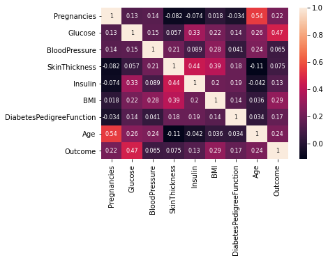

```python
# визуализируем коэффициенты корреляции

import seaborn as sns
sns.heatmap(data.corr(), annot=True, annot_kws={'size': 8})
```

**По вычисленной тепловой карте сделайте вывод: Какие признаки сильно коррелируют друг с другом?**  
Как правило, если корреляция между парой переменных превышает 0,5–0,6, нам следует серьезно подумать об исключении одной из этих переменных (удаление переменной очень субъективно и всегда должно производиться с учетом предметной области).  
Делаем выводы о сильнокоррелированных признаках и удаляем один из них.